# CWM_Models

Maggie Klope

## GLMs for Community-weighted means (CWMs)

- Calculated with 2017 trait data
- again, one value per climate/treatment/block so no blocking effect included
- Include interaction between climate and treatment? AIC values for some are much higher without interaction

### Models:

**What is the effect of climate and grazing on community-weighted means?**

`lm(LA ~ Climate * Treatment, family = gaussian)`

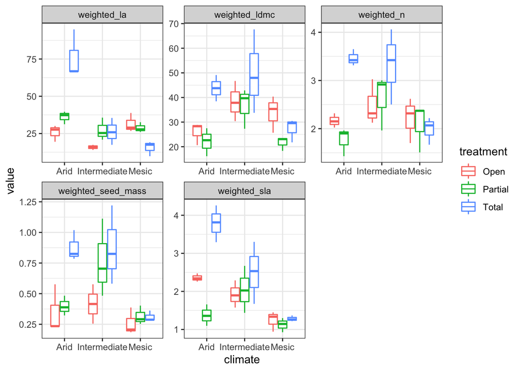

```r
cwm_traits_adj %>%
  pivot_longer(cols = weighted_la:weighted_n,
               names_to = "traits",
               values_to = "value") %>%
  ggplot(aes(x = climate, y = value, color = treatment)) +
  geom_boxplot() +
  theme_bw() +
  facet_wrap(~traits, scales = "free")
```

#### a. Leaf Area CWM

- Arid Total LA CWM larger than all other plots
- Arid:
  - Arid Total > Arid Open and Arid Partial
  - No difference between Arid Open and Arid Partial
- Intermediate:
  - No difference between herbivore treatments
- Mesic:
  - No difference between herbivore treatments
- Total herbivore treatment:
  - Arid Total larger than Intermediate Total and Mesic Total
  - No difference between Int Total and Mesic Total
- No differences between Open or Partial Treatments across climates

```r
# Best fit model:
LA_CWM <- glm(data = cwm_traits_adj, weighted_la ~ climate * treatment, family = gaussian, na.action = na.fail)
LA_CWM <- glmmTMB(data = cwm_traits_adj, weighted_la ~ climate * treatment, family = gaussian)
dredge(LA_CWM) #best model: weighted_la ~ climate * treatment
```

```
## Fixed terms are "cond((Int))" and "disp((Int))"
```

```
## Global model call: glmmTMB(formula = weighted_la ~ climate * treatment, data = cwm_traits_adj,
##     family = gaussian, ziformula = ~0, dispformula = ~1)
## ---
## Model selection table
##   cnd((Int)) dsp((Int)) cnd(clm) cnd(trt) cnd(clm:trt) df   logLik  AICc delta
## 8      25.74          +        +        +            + 10  -87.924 209.6  0.00
## 2      45.97          +        +                        4 -111.244 232.3 22.71
## 4      38.86          +        +        +               6 -108.753 233.7 24.11
## 1      31.46          +                                 2 -116.518 237.5 27.94
## 3      24.35          +                 +               4 -114.884 239.6 29.99
##   weight
## 8      1
## 2      0
## 4      0
## 1      0
## 3      0
## Models ranked by AICc(x)
```

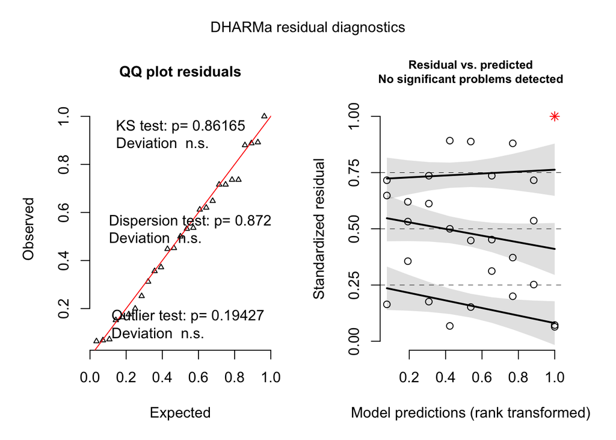

```
## Object of Class DHARMa with simulated residuals based on 250 simulations with refit = FALSE . See ?DHARMa::simulateResiduals for help.
##
## Scaled residual values: 0.176 0.612 0.736 0.252 0.716 0.536 0.064 1 0.072 0.532 0.356 0.62 0.448 0.888 0.152 0.5 0.068 0.892 0.372 0.88 ...
```

```r
# Checking data
(simulateResiduals(LA_CWM, plot= T)) #What is the red asterisk on the model predictions graph?
```

```r
(shapiro.test(residuals(LA_CWM))) #normal
```

```
##
##  Shapiro-Wilk normality test
##
## data:  residuals(LA_CWM)
## W = 0.94943, p-value = 0.2076
```

```r
# Model summaries
LA_sig_pairs <-  as.data.frame(pairs(emmeans(LA_CWM, ~climate * treatment))) %>%
  filter(p.value <= 0.05)

emmeans(LA_CWM, pairwise ~ climate * treatment)
```

```
## $emmeans
##  climate      treatment emmean   SE df lower.CL upper.CL
##  Arid         Open        25.7 3.63 17    18.08     33.4
##  Intermediate Open        15.8 3.63 17     8.16     23.5
##  Mesic        Open        31.5 3.63 17    23.86     39.2
##  Arid         Partial     36.1 3.63 17    28.43     43.7
##  Intermediate Partial     27.3 3.63 17    19.65     34.9
##  Mesic        Partial     28.8 3.63 17    21.18     36.5
##  Arid         Total       76.1 3.63 17    68.44     83.7
##  Intermediate Total       26.3 3.63 17    18.60     33.9
##  Mesic        Total       15.5 3.63 17     7.84     23.1
##
## Confidence level used: 0.95
##
## $contrasts
##  contrast                                  estimate   SE df t.ratio p.value
##  Arid,Open - Intermediate,Open                9.929 5.13 17   1.936 0.6010
##  Arid,Open - Mesic,Open                      -5.779 5.13 17  -1.127 0.9615
##  Arid,Open - Arid,Partial                   -10.342 5.13 17  -2.017 0.5527
##  Arid,Open - Intermediate,Partial            -1.562 5.13 17  -0.305 1.0000
##  Arid,Open - Mesic,Partial                   -3.098 5.13 17  -0.604 0.9993
##  Arid,Open - Arid,Total                     -50.353 5.13 17  -9.819 <.0001
##  Arid,Open - Intermediate,Total              -0.520 5.13 17  -0.101 1.0000
##  Arid,Open - Mesic,Total                     10.242 5.13 17   1.997 0.5644
##  Intermediate,Open - Mesic,Open             -15.708 5.13 17  -3.063 0.1182
##  Intermediate,Open - Arid,Partial           -20.271 5.13 17  -3.953 0.0219
##  Intermediate,Open - Intermediate,Partial   -11.491 5.13 17  -2.241 0.4245
##  Intermediate,Open - Mesic,Partial          -13.027 5.13 17  -2.540 0.2796
##  Intermediate,Open - Arid,Total             -60.282 5.13 17 -11.755 <.0001
##  Intermediate,Open - Intermediate,Total     -10.448 5.13 17  -2.037 0.5404
##  Intermediate,Open - Mesic,Total              0.314 5.13 17   0.061 1.0000
##  Mesic,Open - Arid,Partial                   -4.563 5.13 17  -0.890 0.9906
##  Mesic,Open - Intermediate,Partial            4.217 5.13 17   0.822 0.9944
##  Mesic,Open - Mesic,Partial                   2.680 5.13 17   0.523 0.9998
##  Mesic,Open - Arid,Total                    -44.574 5.13 17  -8.692 <.0001
##  Mesic,Open - Intermediate,Total              5.259 5.13 17   1.026 0.9776
##  Mesic,Open - Mesic,Total                    16.021 5.13 17   3.124 0.1060
##  Arid,Partial - Intermediate,Partial          8.780 5.13 17   1.712 0.7323
##  Arid,Partial - Mesic,Partial                 7.244 5.13 17   1.413 0.8782
##  Arid,Partial - Arid,Total                  -40.011 5.13 17  -7.802 <.0001
##  Arid,Partial - Intermediate,Total            9.823 5.13 17   1.915 0.6134
##  Arid,Partial - Mesic,Total                  20.584 5.13 17   4.014 0.0194
##  Intermediate,Partial - Mesic,Partial        -1.536 5.13 17  -0.300 1.0000
##  Intermediate,Partial - Arid,Total          -48.791 5.13 17  -9.514 <.0001
##  Intermediate,Partial - Intermediate,Total    1.042 5.13 17   0.203 1.0000
##  Intermediate,Partial - Mesic,Total          11.804 5.13 17   2.302 0.3920
##  Mesic,Partial - Arid,Total                 -47.255 5.13 17  -9.214 <.0001
##  Mesic,Partial - Intermediate,Total           2.579 5.13 17   0.503 0.9998
##  Mesic,Partial - Mesic,Total                 13.341 5.13 17   2.601 0.2548
##  Arid,Total - Intermediate,Total             49.833 5.13 17   9.717 <.0001
##  Arid,Total - Mesic,Total                    60.595 5.13 17  11.816 <.0001
##  Intermediate,Total - Mesic,Total            10.762 5.13 17   2.099 0.5045
##
## P value adjustment: tukey method for comparing a family of 9 estimates
```

#### b. SLA CWM

```r
# best fit model
SLA_CWM <- glmmTMB(data = cwm_traits_adj, weighted_sla ~ climate * treatment, family = gaussian)
dredge(SLA_CWM) #best model: weighted_sla ~ climate * treatment
```

```
## Fixed terms are "cond((Int))" and "disp((Int))"
```

```
## Global model call: glmmTMB(formula = weighted_sla ~ climate * treatment, data = cwm_traits_adj,
##     family = gaussian, ziformula = ~0, dispformula = ~1)
## ---
## Model selection table
##   cnd((Int)) dsp((Int)) cnd(clm) cnd(trt) cnd(clm:trt) df  logLik AICc delta
## 8      2.358          +        +        +            + 10  -9.587 52.9  0.00
## 4      2.387          +        +        +               6 -21.698 59.6  6.67
## 2      2.506          +        +                        4 -28.114 66.0 13.12
## 3      1.840          +                 +               4 -31.154 72.1 19.20
## 1      1.959          +                                 2 -34.717 73.9 21.01
##   weight
## 8  0.964
## 4  0.034
## 2  0.001
## 3  0.000
## 1  0.000
## Models ranked by AICc(x)
```

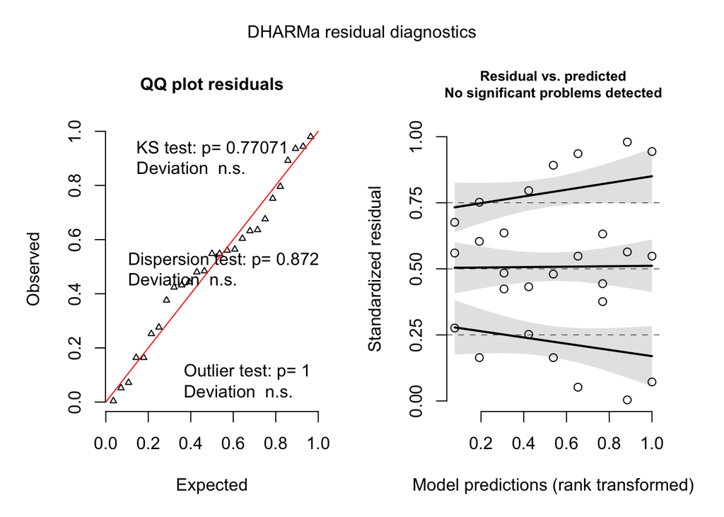

```
## Object of Class DHARMa with simulated residuals based on 250 simulations with refit = FALSE . See ?DHARMa::simulateResiduals for help.
##
## Scaled residual values: 0.632 0.376 0.444 0.252 0.796 0.432 0.548 0.944 0.072 0.48 0.164 0.892 0.052 0.936 0.548 0.564 0.004 0.98 0.604 0.752 ...
```

```r
#NEED TO DO MODEL AVERAGE

# testing data
simulateResiduals(SLA_CWM, plot= T) #looks good
```

```r
shapiro.test(residuals(SLA_CWM)) #normal
```

```
##
##  Shapiro-Wilk normality test
##
## data:  residuals(SLA_CWM)
## W = 0.97047, p-value = 0.6143
```

```r
# model summary
summary(SLA_CWM)
```

```
##  Family: gaussian  ( identity )
## Formula:          weighted_sla ~ climate * treatment
## Data: cwm_traits_adj
##
##      AIC      BIC   logLik deviance df.resid
##     39.2     52.1     -9.6     19.2       17
##
##
## Dispersion estimate for gaussian family (sigma^2): 0.119
##
## Conditional model:
##                                      Estimate Std. Error z value Pr(>|z|)
## (Intercept)                            2.3580     0.1993  11.834  < 2e-16 ***
## climateIntermediate                   -0.4381     0.2818  -1.555 0.120054
## climateMesic                          -1.1160     0.2818  -3.961 7.48e-05 ***
## treatmentPartial                      -0.9872     0.2818  -3.503 0.000460 ***
## treatmentTotal                         1.4303     0.2818   5.076 3.86e-07 ***
## climateIntermediate:treatmentPartial   1.1111     0.3985   2.788 0.005299 **
## climateMesic:treatmentPartial          0.8686     0.3985   2.180 0.029278 *
## climateIntermediate:treatmentTotal    -0.8483     0.3985  -2.129 0.033276 *
## climateMesic:treatmentTotal           -1.3889     0.3985  -3.485 0.000492 ***
## ---
## Signif. codes:  0 '***' 0.001 '**' 0.01 '*' 0.05 '.' 0.1 ' ' 1
```

```r
SLA_sig_pairs <- as.data.frame(pairs(emmeans(SLA_CWM, ~climate * treatment)))%>%
  filter(p.value <= 0.05)
SLA_sig_pairs
```

```
##                              contrast  estimate        SE df   t.ratio
## 1              Arid,Open - Mesic,Open  1.116047 0.2817878 17  3.960593
## 2           Arid,Open - Mesic,Partial  1.234598 0.2817878 17  4.381303
## 3              Arid,Open - Arid,Total -1.430333 0.2817878 17 -5.075922
## 4             Arid,Open - Mesic,Total  1.074643 0.2817878 17  3.813661
## 5      Intermediate,Open - Arid,Total -1.868385 0.2817878 17 -6.630469
## 6             Mesic,Open - Arid,Total -2.546380 0.2817878 17 -9.036515
## 7     Mesic,Open - Intermediate,Total -1.260007 0.2817878 17 -4.471475
## 8           Arid,Partial - Arid,Total -2.417519 0.2817878 17 -8.579217
## 9   Arid,Partial - Intermediate,Total -1.131146 0.2817878 17 -4.014176
## 10  Intermediate,Partial - Arid,Total -1.744425 0.2817878 17 -6.190564
## 11         Mesic,Partial - Arid,Total -2.664931 0.2817878 17 -9.457225
## 12 Mesic,Partial - Intermediate,Total -1.378558 0.2817878 17 -4.892185
## 13    Arid,Total - Intermediate,Total  1.286373 0.2817878 17  4.565040
## 14           Arid,Total - Mesic,Total  2.504976 0.2817878 17  8.889583
```

[output cut: 17 more lines]

```r
emmeans(SLA_CWM, pairwise ~ climate * treatment)
```

```
## $emmeans
##  climate      treatment emmean    SE df lower.CL upper.CL
##  Arid         Open        2.36 0.199 17    1.938     2.78
##  Intermediate Open        1.92 0.199 17    1.500     2.34
##  Mesic        Open        1.24 0.199 17    0.822     1.66
##  Arid         Partial     1.37 0.199 17    0.950     1.79
##  Intermediate Partial     2.04 0.199 17    1.624     2.46
##  Mesic        Partial     1.12 0.199 17    0.703     1.54
##  Arid         Total       3.79 0.199 17    3.368     4.21
##  Intermediate Total       2.50 0.199 17    2.082     2.92
##  Mesic        Total       1.28 0.199 17    0.863     1.70
##
## Confidence level used: 0.95
##
## $contrasts
##  contrast                                  estimate    SE df t.ratio p.value
##  Arid,Open - Intermediate,Open               0.4381 0.282 17  1.555  0.8153
##  Arid,Open - Mesic,Open                      1.1160 0.282 17  3.961  0.0216
##  Arid,Open - Arid,Partial                    0.9872 0.282 17  3.503  0.0525
##  Arid,Open - Intermediate,Partial            0.3141 0.282 17  1.115  0.9638
##  Arid,Open - Mesic,Partial                   1.2346 0.282 17  4.381  0.0093
##  Arid,Open - Arid,Total                     -1.4303 0.282 17 -5.076  0.0023
##  Arid,Open - Intermediate,Total             -0.1440 0.282 17 -0.511  0.9998
##  Arid,Open - Mesic,Total                     1.0746 0.282 17  3.814  0.0288
##  Intermediate,Open - Mesic,Open              0.6780 0.282 17  2.406  0.3399
##  Intermediate,Open - Arid,Partial            0.5491 0.282 17  1.949  0.5933
##  Intermediate,Open - Intermediate,Partial   -0.1240 0.282 17 -0.440  0.9999
##  Intermediate,Open - Mesic,Partial           0.7965 0.282 17  2.827  0.1775
##  Intermediate,Open - Arid,Total             -1.8684 0.282 17 -6.630  0.0001
##  Intermediate,Open - Intermediate,Total     -0.5820 0.282 17 -2.065  0.5239
##  Intermediate,Open - Mesic,Total             0.6366 0.282 17  2.259  0.4145
##  Mesic,Open - Arid,Partial                  -0.1289 0.282 17 -0.457  0.9999
##  Mesic,Open - Intermediate,Partial          -0.8020 0.282 17 -2.846  0.1719
##  Mesic,Open - Mesic,Partial                  0.1186 0.282 17  0.421  1.0000
##  Mesic,Open - Arid,Total                    -2.5464 0.282 17 -9.037  <.0001
##  Mesic,Open - Intermediate,Total            -1.2600 0.282 17 -4.471  0.0078
##  Mesic,Open - Mesic,Total                   -0.0414 0.282 17 -0.147  1.0000
##  Arid,Partial - Intermediate,Partial        -0.6731 0.282 17 -2.389  0.3483
##  Arid,Partial - Mesic,Partial                0.2474 0.282 17  0.878  0.9914
##  Arid,Partial - Arid,Total                  -2.4175 0.282 17 -8.579  <.0001
##  Arid,Partial - Intermediate,Total          -1.1311 0.282 17 -4.014  0.0194
##  Arid,Partial - Mesic,Total                  0.0875 0.282 17  0.310  1.0000
##  Intermediate,Partial - Mesic,Partial        0.9205 0.282 17  3.267  0.0818
##  Intermediate,Partial - Arid,Total          -1.7444 0.282 17 -6.191  0.0003
##  Intermediate,Partial - Intermediate,Total  -0.4581 0.282 17 -1.626  0.7794
##  Intermediate,Partial - Mesic,Total          0.7606 0.282 17  2.699  0.2186
##  Mesic,Partial - Arid,Total                 -2.6649 0.282 17 -9.457  <.0001
##  Mesic,Partial - Intermediate,Total         -1.3786 0.282 17 -4.892  0.0033
##  Mesic,Partial - Mesic,Total                -0.1600 0.282 17 -0.568  0.9996
##  Arid,Total - Intermediate,Total             1.2864 0.282 17  4.565  0.0065
##  Arid,Total - Mesic,Total                    2.5050 0.282 17  8.890  <.0001
##  Intermediate,Total - Mesic,Total            1.2186 0.282 17  4.325  0.0104
##
## P value adjustment: tukey method for comparing a family of 9 estimates
```

```r
# plot(pairs(emmeans(SLA_CWM, ~climate * treatment))) +
#   theme_bw(base_size = 18) +
#   geom_vline(xintercept=0, size=2, color="red")
```